# Problem 2

2023-11-23

Swissvar is a database of human gene, their variations, and disease associations. The file can be downloaded from here: https://ftp.uniprot.org/pub/databases/uniprot/current_release/knowledgebase/variants/humsavar.txt. The first column of this file contains the gene name and the rest of the columns contains the other information. Using this file:

1. list out the top five genes that are mutated in various human disease.

```r
# download.file("https://ftp.uniprot.org/pub/databases/uniprot/current_release/knowledgebase/variants/humsavar.txt", destfile = "humsavar.txt")

humsavar_lines <- readLines("humsavar.txt")
# head(humsavar_lines, n = 45)
# tail(humsavar_lines)

start <- grep("^gene name", humsavar_lines)
end <- grep("^$", humsavar_lines)
end <- end[length(end)]

humsavar <- humsavar_lines[(start+2):(end-1)]
# head(humsavar, n = 2); tail(humsavar, n = 2)

df <- read.table(textConnection(humsavar), fill = T, stringsAsFactors = T, sep = "", flush = T)
# humsavar_lines[start]
names(df) <- c("gene_name", "accession", "FTId", "aa_change", "var_category", "dbSNP", "disease_name")
df <- df[!colnames(df) %in% "disease_name"]

dis_vars <- df |>
  filter(var_category %in% "LP/P") |>
  summarise(.by = c("gene_name", "accession"), n = n()) |>
  arrange(desc(n))

# write_tsv(dis_vars, "../data/dis_vars.tsv")

dis_vars |> slice_head(n = 5)
```

```
##   gene_name accession   n
## 1        F8    P00451 468
## 2     SCN1A    P35498 409
## 3      FBN1    P35555 393
## 4     ABCA4    P78363 226
## 5       PAH    P00439 226
```

2. plot the frequency distribution of disease variants in human genome across all the genes in the file.
3. calculate the average number disease causing mutations across all genes in human genome and mark this number on the previous plot as veritcal red line.

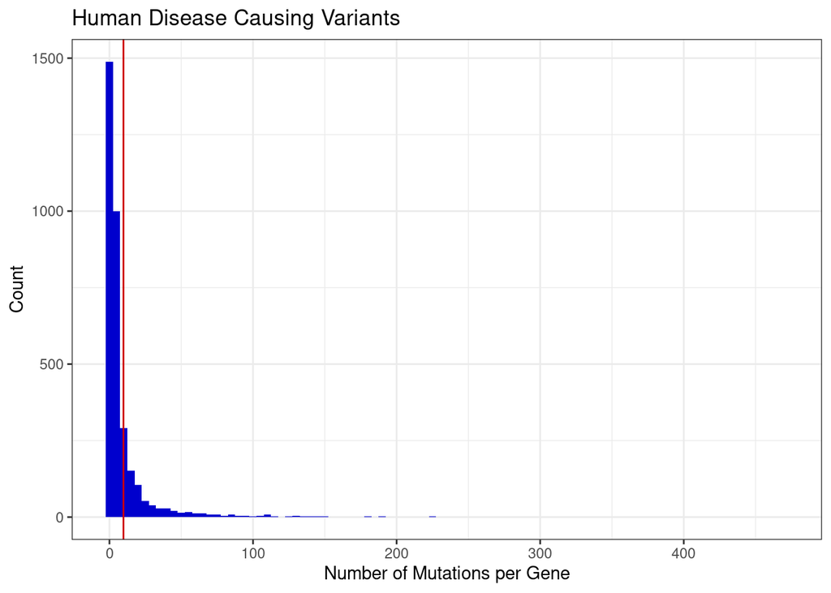

```r
ggplot(dis_vars, aes(x = n)) +
  geom_histogram(binwidth = 5, fill = "blue3") +
  geom_vline(xintercept = mean(dis_vars$n), color = "red3") +
  labs(x = "Number of Mutations per Gene", y = "Count", title = "Human Disease Causing Variants")+
  theme_bw()
```

4. The 4th column of this file contains the amino acid affected by the the mutation like this: p.Gly477Arg. The p indicates it is protein sequence. Then the 3 letter code of the aa affected then the position in number and then three letter code for the aa that the position changed to. You should write a regular expression to extract the affected aa. Plot a graph showing the fraction of mutations affecting each 20 amino acid on the x-axis. Which amino acid has the highest probablity of getting mutated? **Arginine has the highest probability of being mutated**

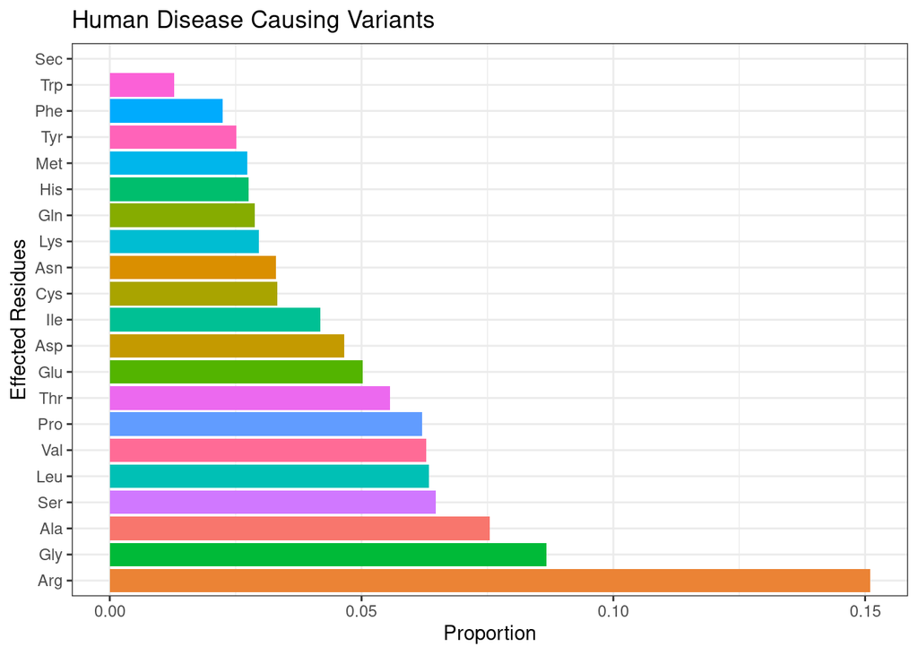

```r
df$effect_res <- str_match(df$aa_change, pattern = "^p.([A-Za-z]+)\\d")[,2]

mut <- df |>
  summarise(.by = effect_res, n = n()) |>
  mutate(prop = n/sum(n))

ggplot(mut, aes(y = prop, x = fct_reorder(effect_res, desc(prop)), fill = effect_res))+
  geom_bar(stat = "identity", show.legend = F) +
  labs(y = "Proportion", x = "Effected Residues", title = "Human Disease Causing Variants") +
  coord_flip() +
  theme_bw()
```